# SAP S4 ↔ Tookane

## Análisis de brechas, propuestas de mejora y automatización

```python
import sys, csv, json, warnings
warnings.filterwarnings('ignore')
sys.stdout.reconfigure(encoding='utf-8') if hasattr(sys.stdout, 'reconfigure') else None

import pandas as pd
import matplotlib.pyplot as plt
import matplotlib.patches as mpatches
from matplotlib.patches import FancyBboxPatch
import psycopg2
from IPython.display import display, HTML, Markdown
from datetime import date

# ── Paleta Actiu ──────────────────────────────────────────────────────────────
P = {
    'navy':   '#1B2D4F',
    'blue':   '#2563EB',
    'teal':   '#0D9488',
    'coral':  '#EF4444',
    'gold':   '#F59E0B',
    'green':  '#16A34A',
    'gray':   '#64748B',
    'light':  '#F1F5F9',
    'purple': '#7C3AED',
    'orange': '#EA580C',
}

# ── Matplotlib global ─────────────────────────────────────────────────────────
plt.rcParams.update({
    'font.family':     'DejaVu Sans',
    'font.size':       11,
    'axes.spines.top':    False,
    'axes.spines.right':  False,
    'figure.dpi':      120,
    'savefig.bbox':    'tight',
    'savefig.pad_inches': 0.15,
})

# ── PostgreSQL ────────────────────────────────────────────────────────────────
try:
    con = psycopg2.connect(
        host='localhost', port=5432, dbname='actiu_co',
        user='postgres', password=''
    )
    cur = con.cursor()
    DB_OK = True
except Exception as e:
    DB_OK = False
    print(f"⚠ Sin conexión a PostgreSQL: {e}")

def q(sql):
    cur.execute(sql)
    cols = [d[0] for d in cur.description]
    return pd.DataFrame(cur.fetchall(), columns=cols)

# ── CSV campos ────────────────────────────────────────────────────────────────
CSV_PATH = r'C:/Users/medina/Downloads/CAMPOS PARA SUBIR A TOOKANE - Hoja 1.csv'
with open(CSV_PATH, encoding='utf-8-sig', newline='') as f:
    raw = list(csv.reader(f))

campos = []
for row in raw[2:]:
    if not any(row): continue
    campos.append({
        'nombre':    row[0].strip(),
        'tabla':     row[1].strip(),
        'campo_sap': row[2].strip(),
        'tookane':   row[3].strip(),
        'ejemplo':   row[4].strip(),
        'notif':     row[5].strip(),
        'uso':       row[7].strip(),
        'comentario':row[8].strip(),
        'descripcion':row[9].strip(),
        'subimos':   row[10].strip().lower() if len(row) > 10 else '',
    })
df_campos = pd.DataFrame(campos)
```

## Por qué la integración entre SAP y Tookane no es óptima

**3. Sincronización manual y tardía** El estado de cada entrega se actualiza cuando alguien descarga el CSV de Tookane manualmente, normalmente 1-2 veces por semana. Los sistemas internos siempre van con varios días de retraso respecto a la realidad del transporte.

**4. Expediciones sin trazabilidad cruzada** 584 expediciones existen en Tookane pero no tienen enlace verificado a SAP. No hay campo común que vincule de forma fiable el pedido SAP con su expedición en Tookane, lo que hace imposible la reconciliación automática.

# 1. Estado de los 26 campos SAP → Tookane

La tabla siguiente evalúa cada campo que SAP debería comunicar a Tookane: si llega en un campo dedicado, si llega dentro del contenedor genérico `extraInfo`, si está parcialmente mapeado o si directamente no se envía.

```python
estado_map = {
    'NO -> EXTRAINFO':   'En EXTRAINFO',
    '':                  'Sin mapear',
    'Dirección de transportista o dirección de plataforma (WZ)': 'Correcto',
    'consumer.notes':    'Correcto',
    'NO -> agreedDeliveryDateFrom y el campo agreedDeliveryDateTo  Type: String (ISO Date)': 'Parcial',
}

subimos_map = {
    'sí': 'Sí',   'si': 'Sí',
    'no': 'No',
    'ya está subido': 'Ya subido',
    'posible': 'A evaluar',
}

rows = []
for _, c in df_campos.iterrows():
    estado_raw = c['tookane'].strip()
    estado_lbl = estado_map.get(estado_raw, 'Sin mapear')
    if 'agreedDelivery' in estado_raw:
        estado_lbl = 'Parcial'
    subir = subimos_map.get(c['subimos'], c['subimos'])
    rows.append({
        'Campo SAP': c['nombre'] if c['nombre'] else '—',
        'Tabla / Campo técnico': f"{c['tabla']}.{c['campo_sap']}" if c['tabla'] else '—',
        'Estado en Tookane': estado_lbl,
        '¿Lo subimos?': subir,
        'Para qué sirve': c['descripcion'] or c['uso'] or '—',
    })

df_tabla = pd.DataFrame(rows)

NEUTRAL_STYLES = [
    {'selector': 'thead th', 'props': [
        ('background-color', '#374151'), ('color', 'white'),
        ('font-weight', 'bold'), ('padding', '8px 12px'), ('font-size', '11px'),
        ('border', '1px solid #D1D5DB'), ('white-space', 'nowrap'),
    ]},
    {'selector': 'tbody td', 'props': [
        ('border', '1px solid #E5E7EB'), ('vertical-align', 'top'),
        ('white-space', 'normal'), ('word-wrap', 'break-word'),
    ]},
    {'selector': 'tbody tr:nth-child(even)', 'props': [('background-color', '#F9FAFB')]},
    {'selector': 'table', 'props': [('border-collapse', 'collapse'), ('width', '100%')]},
]

styled_tabla = (df_tabla.style
    .set_properties(**{'font-size': '11px', 'text-align': 'left', 'padding': '6px 12px'})
    .set_table_styles(NEUTRAL_STYLES)
    .hide(axis='index')
    .set_caption('Tabla 1 · Estado de los 26 campos SAP → Tookane')
)
display(styled_tabla)
```

Tabla 1 · Estado de los 26 campos SAP → Tookane

| Campo SAP | Tabla / Campo técnico | Estado en Tookane | ¿Lo subimos? | Para qué sirve |
| --- | --- | --- | --- | --- |
| Itin. transporte | VTTK.ROUTE | En EXTRAINFO | Sí | RUTA Ejemplo ES028 |
| Cl. exped. | VTTK.VSART | En EXTRAINFO | Sí | tipo de vehículo (jumbo, tráiler) |
| Cl. med. transpo. | VTTK.BFART | Sin mapear | A evaluar | tipo de estiba (granel, paletozado) |
| Matric. Vehic | VTTK.SIGNI | En EXTRAINFO | Sí | Campo donde indicar la matrícula del vehículo |
| PesTotPerm | VTTK.ALLOWED_TWGT | Sin mapear | No | Peso total permitido del transporte |
| Pl. itinerarios | VTTK.AULWE | Sin mapear | A evaluar | Se puede usar para plafinicar los itinerarios qué hacer cada semana, horas a las de entregar. |
| Condic. exped. | VTTK.VSBED | En EXTRAINFO | Ya subido | Tipo servicio de la Empresa transporte (Directo, express plat...) |
| Matric. Remol. | VTTK.EXTI1 | Sin mapear | A evaluar | Nº de matrícula para el remolque |
| Gest especial | — | Sin mapear | A evaluar | Indicar la urgencia |
| Func. interl. (WZ) | SDPARTNERLIST.PARVW | Correcto | Sí | Función de Interlocutor indicado desde el pedido (Transportista, Plataforma, Dirección de plataforma) |
| Interl. | SDPARTNERLIST.PARTNER_EXT | Correcto | Sí | Interlocutor indicado desde el pedido. Nº de BP |
| Txt | — | Sin mapear | A evaluar | Orden transportista |
| Tipo Envío | VTTK.ADD03 | En EXTRAINFO | Sí | Marca el tipo de envío (estándard, rápido y con fecha concreta) |
| Fecha concreta | VTTK.TEXT2 | Parcial | Sí | Marca la fecha y hora en la que se tiene que realizar el tipo de envío de fecha concreta |
| Sin Etiq Bulto | VTTK.ADD01 | Sin mapear | A evaluar | Marcaremos esta opción cuando desde planificación de transporte esa mercancía tiene que ir a granel, es decir, sin etiqueta bulto |
| Prepar. clte. | VTTK.ADD02 | Sin mapear | A evaluar | Indica si la expedición debe ir agrupada por cliente |
| Orient. Cab. | VTTK.ADD04 | Sin mapear | A evaluar | Indica la orientación del caballete |
| Comentarios | ADDR1_DATA.REMARK | Correcto | Sí | Comentarios referente a la dirección dentro del BP |
| Referencia cliente | VBKD.BSTKD | En EXTRAINFO | Sí | Datos extra que indican en el pedido. |
| Función de interlocutor (M1) | SDPARTNERLIST.PARVW | En EXTRAINFO | Sí | Función de Interlocutor indicado desde el pedido (Transportista, Plataforma, Dirección de plataforma). Si está activado el M1, que lo muestre |
| Clase de pedido | VBAK.AUART | En EXTRAINFO | Sí | Indica el tipo de pedido si es un pedido normal, de consigna o de devolución |
| Causa de la incidencia | VIQMEL.QMGRP | En EXTRAINFO | Sí | Información de la incidencia/aviso |
| Causa 2 de la incidencia | VIQMEL.QMCOD | En EXTRAINFO | Sí | Información de la incidencia/aviso |
| Clase de aviso | VIQMEL.QMARTE | En EXTRAINFO | Sí | Tipo de incidencia por ejemplo si es rotura |
| HU Expedición | V51VE.EXIDV | En EXTRAINFO | Sí | HU asignada a la expedición |
| — | — | Sin mapear |  | — |

# 2. Propuesta de automatizaciones

El objetivo es eliminar el trabajo manual repetitivo y hacer que el ciclo de vida de cada envío quede trazado automáticamente — desde que SAP lo crea hasta que se entrega al cliente.

El corazón de la propuesta: **N8N como nexo central** entre SAP, Tookane y PostgreSQL. SAP genera el envío → N8N lo publica en Tookane → Tookane devuelve cada cambio de estado → N8N lo guarda en PostgreSQL. Todo el ciclo queda registrado sin intervención manual.

## 2.1 La arquitectura propuesta

El flujo es lineal y sin intervención manual:

1. **SAP crea un envío** → N8N lo lee (OData VTTK) y lo publica en Tookane con los datos correctos
2. **Tookane gestiona el envío** (asigna carrier, genera tracking, coordina la entrega)
3. **Tookane avisa via webhook** de cada cambio de estado → N8N lo recibe y lo guarda en PostgreSQL
4. **PostgreSQL acumula el ciclo completo**: creación, asignación, salida, incidencias, entrega

Eso es toda la integración con Tookane. El resto de workflows (alertas, casos CO, Google Sheets) leen de PostgreSQL — nunca consultan Tookane directamente.

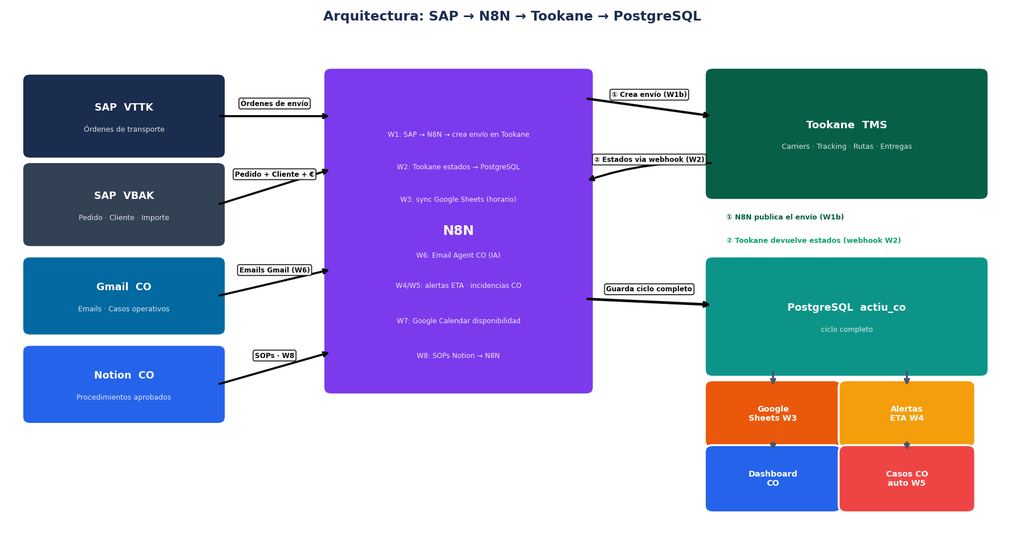

```python
fig, ax = plt.subplots(figsize=(15, 8))
fig.patch.set_facecolor('white')
ax.set_facecolor('white')
ax.set_xlim(0, 15); ax.set_ylim(0, 8.5)
ax.axis('off')

def box(ax, x, y, w, h, color, label, sublabel='', fontsize=10.5, alpha_bg=1.0):
    rect = FancyBboxPatch((x, y), w, h, boxstyle='round,pad=0.12',
                          facecolor=color, edgecolor='white', linewidth=2, alpha=alpha_bg)
    ax.add_patch(rect)
    ax.text(x + w/2, y + h/2 + (0.15 if sublabel else 0), label,
            ha='center', va='center', fontsize=fontsize, fontweight='bold', color='white')
    if sublabel:
        ax.text(x + w/2, y + h/2 - 0.22, sublabel,
                ha='center', va='center', fontsize=7.5, color=(1,1,1,0.85))

def arrow(ax, x1, y1, x2, y2, label='', color='#475569', lw=2.2, rad=0, ls='-'):
    ax.annotate('', xy=(x2, y2), xytext=(x1, y1),
                arrowprops=dict(arrowstyle='->', color=color, lw=lw,
                                connectionstyle=f'arc3,rad={rad}',
                                linestyle=ls))
    if label:
        mx, my = (x1+x2)/2, (y1+y2)/2
        ax.text(mx, my + 0.18, label, ha='center', fontsize=7.2, color=color,
                fontweight='bold',
                bbox=dict(boxstyle='round,pad=0.25', facecolor='white',
                          edgecolor=color+'50', alpha=0.92))

# ── SAP (izquierda) ──────────────────────────────────────────────────────────
box(ax, 0.3, 6.5, 2.8, 1.2, P['navy'],   'SAP  VTTK',    'Órdenes de transporte')
box(ax, 0.3, 5.0, 2.8, 1.2, '#334155', 'SAP  VBAK',    'Pedido · Cliente · Importe')
box(ax, 0.3, 3.5, 2.8, 1.1, '#0369A1', 'Gmail  CO',    'Emails · Casos operativos')

# ── Notion (izquierda abajo) ────────────────────────────────────────────────
box(ax, 0.3, 2.0, 2.8, 1.1, P['blue'],  'Notion  CO',   'Procedimientos aprobados')

# ── N8N (centro) ──────────────────────────────────────────────────────────────
box(ax, 4.8, 2.5, 3.8, 5.3, P['purple'],
    'N8N', fontsize=14)
# Etiquetas de workflows dentro de N8N
for txt, vy in [('W1: SAP → N8N → crea envío en Tookane',    6.75),
                ('W2: Tookane estados → PostgreSQL',     6.2),
                ('W3: sync Google Sheets (horario)',     5.65),
                ('W6: Email Agent CO (IA)',               4.70),
                ('W4/W5: alertas ETA · incidencias CO',  4.20),
                ('W7: Google Calendar disponibilidad',   3.59),
                ('W8: SOPs Notion → N8N',   3.0)]: # Últimos 3 workflows añadidos recientemente
    ax.text(6.7, vy, txt, ha='center', fontsize=7.3, color='white', alpha=0.88)

# ── TOOKANE (derecha arriba) — bidireccional ──────────────────────────────────
box(ax, 10.5, 5.8, 4.0, 2.0, '#065F46', 'Tookane  TMS',
    'Carriers · Tracking · Rutas · Entregas', fontsize=11)

# Ciclo SAP → N8N → Tookane → N8N → PostgreSQL
ax.text(10.7, 5.35, '① N8N publica el envío (W1b)', fontsize=7.5,
        color='#065F46', fontweight='bold')
ax.text(10.7, 4.95, '② Tookane devuelve estados (webhook W2)', fontsize=7.5,
        color='#0E9F6E', fontweight='bold')

# ── POSTGRESQL (derecha centro) ───────────────────────────────────────────────
box(ax, 10.5, 2.8, 4.0, 1.8, P['teal'],
    'PostgreSQL  actiu_co',
    'ciclo completo')

# ── OUTPUTS (derecha abajo) ───────────────────────────────────────────────────
box(ax, 10.5, 1.6, 1.8, 0.9, P['orange'], 'Google\nSheets W3',  fontsize=8.5)
box(ax, 12.5, 1.6, 1.8, 0.9, P['gold'],   'Alertas\nETA W4',    fontsize=8.5)
box(ax, 10.5, 0.5, 1.8, 0.9, P['blue'],   'Dashboard\nCO',      fontsize=8.5)
box(ax, 12.5, 0.5, 1.8, 0.9, P['coral'],  'Casos CO\nauto W5',  fontsize=8.5)

# ── FLECHAS: SAP → N8N ────────────────────────────────────────────────────────
arrow(ax, 3.1, 7.1,  4.8, 7.1, 'Órdenes de envío', "#080808")
arrow(ax, 3.1, 5.6,  4.8, 6.2, 'Pedido + Cliente + €', "#080808")
arrow(ax, 3.1, 4.05, 4.8, 4.5, 'Emails Gmail (W6)', "#080808")
arrow(ax, 3.1, 2.55, 4.8, 3.1, 'SOPs · W8', "#080808")

# ── FLECHAS: N8N ↔ Tookane (ciclo) ───────────────────────────────────────────
arrow(ax, 8.6, 7.4, 10.5, 7.1, '① Crea envío (W1b)', "#080808", lw=2.5)
arrow(ax, 10.5, 6.3, 8.6, 6.0, '② Estados via webhook (W2)', "#080808", rad=0.1)

# ── FLECHA: N8N → PostgreSQL ──────────────────────────────────────────────────
arrow(ax, 8.6, 4.0, 10.5, 3.9, 'Guarda ciclo completo', "#080808", lw=2.8)

# ── FLECHAS: PostgreSQL → Outputs ────────────────────────────────────────────
arrow(ax, 11.4, 2.8, 11.4, 2.5)
arrow(ax, 13.4, 2.8, 13.4, 2.5)
arrow(ax, 11.4, 1.6, 11.4, 1.4)
arrow(ax, 13.4, 1.6, 13.4, 1.4)

ax.set_title('Arquitectura: SAP → N8N → Tookane → PostgreSQL',
             fontsize=14, fontweight='bold', color=P['navy'], pad=14)
plt.tight_layout()
plt.savefig('fig_arquitectura.png', dpi=130, bbox_inches='tight')
plt.show()
print("")
```

## ¿Por qué N8N como hub central?

Una pregunta natural es si SAP o Tookane podrían hacer este trabajo internamente. No:

- **SAP** es el sistema de registro — no está diseñado para publicar eventos en tiempo real a sistemas externos sin desarrollo ABAP
- **Tookane** gestiona la logística de transporte — no habla con SAP ni con los sistemas internos de Actiu

**N8N es el nexo** que conecta los tres sistemas y decide qué datos van a dónde:

| Sistema | Rol | N8N lee | N8N escribe |
| --- | --- | --- | --- |
| **SAP** | Source of truth: pedidos y transportes (VBAK, VTTK) | ✅ OData en tiempo real | ✗ Solo lectura |
| **Tookane** | TMS: gestión del envío, carrier, tracking, entrega | ✅ Webhooks de estado | ✅ Crea y actualiza envíos |
| **PostgreSQL** | Hub de datos: ciclo completo de cada envío + CO | ✅ Consultas por workflows | ✅ Almacena todo |
| **Google Sheets** | Seguimiento operativo del equipo CO | ✗ | ✅ Sync horario automático |

**Ventajas de este modelo:**

1. **Un ciclo trazado de punta a punta**: desde que SAP crea el transporte hasta la entrega, cada evento queda en PostgreSQL sin intervención manual
2. **Tookane siempre tiene los datos SAP correctos**: N8N traduce el formato SAP al formato Tookane en el momento de la creación del envío
3. **Coste de cambio mínimo**: modificar la lógica de integración cuesta horas en N8N, no semanas en SAP o Tookane
4. **Sin riesgo para el ERP**: ningún sistema externo escribe en SAP

## 2.2 ¿Qué resuelve esta arquitectura?

| Problema actual | Cómo lo resuelve |
| --- | --- |
| Seguimiento manual del estado de cada envío | Tookane avisa a N8N via webhook en cada cambio; PostgreSQL acumula el ciclo completo |
| Google Sheets desactualizado | N8N sincroniza el sheet cada hora con datos reales de PostgreSQL |
| Campos SAP incorrectos en Tookane (EXTRAINFO) | N8N transforma los datos SAP al formato correcto de Tookane antes de crear el envío |
| Incidencias detectadas tarde | Cada webhook de Tookane con cambio de estado activa la creación/actualización del caso CO |
| Correos CO sin contexto logístico | N8N enriquece cada email con datos de PostgreSQL (carrier, ETA, estado actual) |
| Técnico asignado sin conocer su disponibilidad real | W7 lee Google Calendar cada mañana — W6 solo asigna a técnicos disponibles ese día |
| SOPs y procedimientos CO desactualizados | W8 sincroniza Notion → PostgreSQL automáticamente; el caso incluye siempre el procedimiento vigente |

# 3. Detalle de cada workflow

Los ocho workflows no son piezas independientes — **se alimentan entre sí** para resolver de forma coordinada múltiples problemas a la vez. Cada uno aporta datos que el siguiente necesita, creando un ciclo que unifica la información y mejora la trazabilidad operativa.

```python
def workflow_card(numero, nombre, color, emoji, trigger, que_hace, quien_se_beneficia, pasos, kpi_antes, kpi_despues):
    html = f"""
    <div style="border:1px solid #E2E8F0;border-radius:12px;margin:16px 0;overflow:hidden;font-family:sans-serif;">
      <div style="background:{color};padding:18px 24px;display:flex;align-items:center;gap:14px;">
        <span style="font-size:2rem;">{emoji}</span>
        <div>
          <div style="color:white;font-size:.8rem;font-weight:600;opacity:.8;">Workflow {numero}</div>
          <div style="color:white;font-size:1.25rem;font-weight:900;">{nombre}</div>
        </div>
      </div>
      <div style="padding:20px 24px;background:white;">
        <div style="display:grid;grid-template-columns:1fr 1fr;gap:20px;margin-bottom:16px;">
          <div>
            <div style="color:#64748B;font-size:.8rem;font-weight:700;text-transform:uppercase;margin-bottom:4px;">¿Cuándo se activa?</div>
            <div style="color:#1E293B;font-size:.95rem;">{trigger}</div>
          </div>
          <div>
            <div style="color:#64748B;font-size:.8rem;font-weight:700;text-transform:uppercase;margin-bottom:4px;">¿Quién se beneficia?</div>
            <div style="color:#1E293B;font-size:.95rem;">{quien_se_beneficia}</div>
          </div>
        </div>
        <div style="background:#F8FAFC;border-radius:8px;padding:14px 18px;margin-bottom:14px;">
          <div style="color:#334155;font-size:.8rem;font-weight:700;margin-bottom:8px;">¿QUÉ HACE PASO A PASO?</div>
          <ol style="margin:0;padding-left:18px;color:#475569;font-size:.9rem;line-height:1.9;">{pasos}</ol>
        </div>
        <div style="display:grid;grid-template-columns:1fr 1fr;gap:12px;">
          <div style="background:#FEE2E2;border-radius:8px;padding:12px 16px;">
            <div style="color:#991B1B;font-size:.75rem;font-weight:700;margin-bottom:4px;">HOY (sin workflow)</div>
            <div style="color:#7F1D1D;font-size:.9rem;">{kpi_antes}</div>
          </div>
          <div style="background:#DCFCE7;border-radius:8px;padding:12px 16px;">
            <div style="color:#166534;font-size:.75rem;font-weight:700;margin-bottom:4px;">CON WORKFLOW</div>
            <div style="color:#14532D;font-size:.9rem;">{kpi_despues}</div>
          </div>
        </div>
      </div>
    </div>
    """
    display(HTML(html))
```

```python
workflow_card(
    numero='W1',
    nombre='SAP → PostgreSQL → Tookane (campos correctamente mapeados)',
    color=P['navy'],
    emoji='📡',
    trigger='Cuando SAP crea o modifica una orden de transporte',
    que_hace='Envía los datos de SAP a Tookane en el formato correcto, con campos dedicados en lugar de EXTRAINFO',
    quien_se_beneficia='Tookane (puede aplicar reglas automáticas) · IT · Equipo logística',
    pasos='''
        <li>SAP crea o modifica un transporte (orden VTTK)</li>
        <li>SAP emite un evento automático que N8N recibe</li>
        <li>N8N transforma los datos: convierte Z000 → STANDARD, Z001 → EXPRESS, etc.</li>
        <li>N8N llama a la API de Tookane con los campos correctos (serviceType, agreedDeliveryDate, etc.)</li>
        <li>Tookane recibe la expedición con toda la información estructurada y puede actuar automáticamente</li>
        <li>N8N guarda el registro en PostgreSQL para trazabilidad completa</li>
    ''',
    kpi_antes='Datos SAP en EXTRAINFO genérico; Tookane no puede aplicar reglas ni automatizaciones sobre ellos',
    kpi_despues='Datos en campos dedicados; Tookane asigna carrier y crea alertas automáticamente'
)
```

📡

Workflow W1

SAP → PostgreSQL → Tookane (campos correctamente mapeados)

¿Cuándo se activa?

Cuando SAP crea o modifica una orden de transporte

¿Quién se beneficia?

Tookane (puede aplicar reglas automáticas) · IT · Equipo logística

¿QUÉ HACE PASO A PASO?

1. SAP crea o modifica un transporte (orden VTTK)

2. SAP emite un evento automático que N8N recibe

3. N8N transforma los datos: convierte Z000 → STANDARD, Z001 → EXPRESS, etc.

4. N8N llama a la API de Tookane con los campos correctos (serviceType, agreedDeliveryDate, etc.)

5. Tookane recibe la expedición con toda la información estructurada y puede actuar automáticamente

6. N8N guarda el registro en PostgreSQL para trazabilidad completa

HOY (sin workflow)

Datos SAP en EXTRAINFO genérico; Tookane no puede aplicar reglas ni automatizaciones sobre ellos

CON WORKFLOW

Datos en campos dedicados; Tookane asigna carrier y crea alertas automáticamente

```python
workflow_card(
    numero='W2',
    nombre='Tookane → PostgreSQL (sincronización en tiempo real)',
    color=P['teal'],
    emoji='🔄',
    trigger='Cuando Tookane cambia el estado de cualquier expedición (entrega confirmada, incidencia detectada, etc.)',
    que_hace='Mantiene PostgreSQL actualizado con el estado real de cada entrega en todo momento',
    quien_se_beneficia='Equipo CO · Técnicos comerciales · Dirección',
    pasos='''
        <li>Tookane detecta un cambio de estado (por ejemplo, una entrega completada)</li>
        <li>Tookane envía una notificación automática a N8N (en menos de un minuto)</li>
        <li>N8N recibe la notificación y extrae los datos relevantes</li>
        <li>N8N actualiza PostgreSQL con el nuevo estado de la expedición</li>
        <li>Si el cambio es relevante (incidencia, retraso), N8N activa otros workflows</li>
    ''',
    kpi_antes='Estado de las entregas actualizado 1-2 veces por semana, mediante descarga manual de CSV',
    kpi_despues='Estado actualizado en menos de 1 minuto, sin intervención humana'
)
```

🔄

Workflow W2

Tookane → PostgreSQL (sincronización en tiempo real)

¿Cuándo se activa?

Cuando Tookane cambia el estado de cualquier expedición (entrega confirmada, incidencia detectada, etc.)

¿Quién se beneficia?

Equipo CO · Técnicos comerciales · Dirección

¿QUÉ HACE PASO A PASO?

1. Tookane detecta un cambio de estado (por ejemplo, una entrega completada)

2. Tookane envía una notificación automática a N8N (en menos de un minuto)

3. N8N recibe la notificación y extrae los datos relevantes

4. N8N actualiza PostgreSQL con el nuevo estado de la expedición

5. Si el cambio es relevante (incidencia, retraso), N8N activa otros workflows

HOY (sin workflow)

Estado de las entregas actualizado 1-2 veces por semana, mediante descarga manual de CSV

CON WORKFLOW

Estado actualizado en menos de 1 minuto, sin intervención humana

```python
workflow_card(
    numero='W3',
    nombre='Google Sheets de seguimiento (automático)',
    color=P['orange'],
    emoji='📊',
    trigger='Cada hora, automáticamente',
    que_hace='Actualiza el fichero de seguimiento de transportes con los datos más recientes de PostgreSQL, sin que nadie tenga que descargarlo ni pegarlo',
    quien_se_beneficia='Técnicos comerciales · Equipo CO · Cualquier persona que use el Excel actual',
    pasos='''
        <li>N8N se activa cada hora de forma programada</li>
        <li>Consulta PostgreSQL: expediciones activas, estados, ETAs, alertas</li>
        <li>Calcula automáticamente qué expediciones tienen la ETA vencida (semáforo rojo)</li>
        <li>Escribe los datos en Google Sheets, organizados por carrier y fecha</li>
        <li>El técnico comercial abre el Sheets y ve todo actualizado, sin hacer nada</li>
    ''',
    kpi_antes='30-45 minutos diarios por técnico descargando CSV, pegando datos en Excel y actualizando colores manualmente',
    kpi_despues='0 minutos de trabajo manual · Datos en tiempo real · Semáforo de alertas automático'
)
```

📊

Workflow W3

Google Sheets de seguimiento (automático)

¿Cuándo se activa?

Cada hora, automáticamente

¿Quién se beneficia?

Técnicos comerciales · Equipo CO · Cualquier persona que use el Excel actual

¿QUÉ HACE PASO A PASO?

1. N8N se activa cada hora de forma programada

2. Consulta PostgreSQL: expediciones activas, estados, ETAs, alertas

3. Calcula automáticamente qué expediciones tienen la ETA vencida (semáforo rojo)

4. Escribe los datos en Google Sheets, organizados por carrier y fecha

5. El técnico comercial abre el Sheets y ve todo actualizado, sin hacer nada

HOY (sin workflow)

30-45 minutos diarios por técnico descargando CSV, pegando datos en Excel y actualizando colores manualmente

CON WORKFLOW

0 minutos de trabajo manual · Datos en tiempo real · Semáforo de alertas automático

```python
workflow_card(
    numero='W4',
    nombre='Alerta proactiva de ETA vencida',
    color=P['gold'],
    emoji='⏰',
    trigger='Cada mañana a las 7:00, automáticamente',
    que_hace='Revisa todas las expediciones con ETA vencida, agrupa por carrier y envía un email de alerta al equipo CO antes de que empiecen a llegar las llamadas de clientes',
    quien_se_beneficia='Equipo CO · Técnicos comerciales',
    pasos='''
        <li>A las 7:00, N8N consulta PostgreSQL: ¿qué expediciones tienen ETA de ayer o antes y no están entregadas?</li>
        <li>Agrupa por transportista: Dachser (X vencidas), DSV (Y vencidas)...</li>
        <li>Genera un email con la lista de vencidas, el contacto del carrier y el histórico de esa ruta</li>
        <li>El equipo CO recibe el email antes de que empiece la jornada</li>
        <li>Pueden actuar proactivamente, antes de que el cliente llame preguntando por su pedido</li>
    ''',
    kpi_antes='El equipo se entera de los retrasos cuando el cliente llama · Revisión manual de ETA vencidas lleva 45-60 min/día',
    kpi_despues='Resumen automático cada mañana con todo listo para actuar · 0 min de revisión manual'
)
```

⏰

Workflow W4

Alerta proactiva de ETA vencida

¿Cuándo se activa?

Cada mañana a las 7:00, automáticamente

¿Quién se beneficia?

Equipo CO · Técnicos comerciales

¿QUÉ HACE PASO A PASO?

1. A las 7:00, N8N consulta PostgreSQL: ¿qué expediciones tienen ETA de ayer o antes y no están entregadas?

2. Agrupa por transportista: Dachser (X vencidas), DSV (Y vencidas)...

3. Genera un email con la lista de vencidas, el contacto del carrier y el histórico de esa ruta

4. El equipo CO recibe el email antes de que empiece la jornada

5. Pueden actuar proactivamente, antes de que el cliente llame preguntando por su pedido

HOY (sin workflow)

El equipo se entera de los retrasos cuando el cliente llama · Revisión manual de ETA vencidas lleva 45-60 min/día

CON WORKFLOW

Resumen automático cada mañana con todo listo para actuar · 0 min de revisión manual

```python
workflow_card(
    numero='W5',
    nombre='Incidencia en Tookane → Caso CO automático',
    color=P['coral'],
    emoji='🚨',
    trigger='Cuando Tookane marca una expedición como «Incidencia»',
    que_hace='Crea automáticamente un caso en el sistema CO con toda la información de la expedición, clasifica el tipo de incidencia y notifica al técnico responsable en menos de 5 minutos',
    quien_se_beneficia='Equipo CO · Cliente final (recibe respuesta más rápida)',
    pasos='''
        <li>Tookane detecta una incidencia (rotura, dirección incorrecta, imposible entrega...)</li>
        <li>Tookane avisa a N8N mediante webhook en menos de 1 minuto</li>
        <li>N8N busca en PostgreSQL toda la información de esa expedición (pedido, cliente, historial)</li>
        <li>N8N clasifica el tipo de incidencia (según patrones aprendidos)</li>
        <li>Se crea un caso CO con toda la información ya cargada</li>
        <li>El técnico CO asignado recibe una notificación con el contexto completo y el SOP a seguir</li>
        <li>El técnico puede responder al cliente con información precisa desde el primer momento</li>
    ''',
    kpi_antes='El equipo se entera de la incidencia cuando el cliente escribe o llama · Lag típico: 24-72 horas',
    kpi_despues='Caso creado automáticamente en < 5 minutos · El técnico actúa antes de que el cliente lo note'
)
```

🚨

Workflow W5

Incidencia en Tookane → Caso CO automático

¿Cuándo se activa?

Cuando Tookane marca una expedición como «Incidencia»

¿Quién se beneficia?

Equipo CO · Cliente final (recibe respuesta más rápida)

¿QUÉ HACE PASO A PASO?

1. Tookane detecta una incidencia (rotura, dirección incorrecta, imposible entrega...)

2. Tookane avisa a N8N mediante webhook en menos de 1 minuto

3. N8N busca en PostgreSQL toda la información de esa expedición (pedido, cliente, historial)

4. N8N clasifica el tipo de incidencia (según patrones aprendidos)

5. Se crea un caso CO con toda la información ya cargada

6. El técnico CO asignado recibe una notificación con el contexto completo y el SOP a seguir

7. El técnico puede responder al cliente con información precisa desde el primer momento

HOY (sin workflow)

El equipo se entera de la incidencia cuando el cliente escribe o llama · Lag típico: 24-72 horas

CON WORKFLOW

Caso creado automáticamente en < 5 minutos · El técnico actúa antes de que el cliente lo note

```python
workflow_card(
    numero='W6',
    nombre='CO Email Agent + Asignación inteligente',
    color=P['purple'],
    emoji='🤖',
    trigger='Cuando llega un correo nuevo al buzón de Customer Operations',
    que_hace='Un agente de IA (Gemini Flash) analiza el email, consulta en tiempo real patrones aprendidos y disponibilidad de técnicos en PostgreSQL, clasifica el tipo de caso y genera un borrador de respuesta — todo sin intervención humana hasta que el técnico lo revisa',
    quien_se_beneficia='Equipo CO · Cliente final (respuesta más rápida y precisa)',
    pasos='''
        <li>Llega un email al buzón CO de Gmail</li>
        <li>N8N extrae asunto, remitente, cuerpo del email y cualquier referencia de pedido</li>
        <li>Un agente IA (Gemini Flash) recibe el email con contexto completo preparado</li>
        <li>El agente consulta PostgreSQL: ¿el asunto coincide con algún patrón de caso aprendido? (tipo de caso + confianza)</li>
        <li>El agente consulta PostgreSQL: ¿qué técnico CO está disponible hoy con menor carga de casos?</li>
        <li>Con esa información el agente clasifica el tipo de caso y redacta el borrador de respuesta</li>
        <li>N8N registra el caso, asigna el técnico y guarda el borrador en PostgreSQL</li>
        <li>El técnico CO recibe el email ya clasificado con el contexto logístico completo y el borrador listo</li>
        <li>El técnico revisa, ajusta si es necesario y envía con un clic</li>
    ''',
    kpi_antes='15-25 minutos por correo buscando información en Tookane y SAP para responder con datos correctos',
    kpi_despues='2-3 minutos por correo · Respuesta con datos precisos en tiempo real · Caso registrado y técnico asignado automáticamente'
)
```

🤖

Workflow W6

CO Email Agent + Asignación inteligente

¿Cuándo se activa?

Cuando llega un correo nuevo al buzón de Customer Operations

¿Quién se beneficia?

Equipo CO · Cliente final (respuesta más rápida y precisa)

¿QUÉ HACE PASO A PASO?

1. Llega un email al buzón CO de Gmail

2. N8N extrae asunto, remitente, cuerpo del email y cualquier referencia de pedido

3. Un agente IA (Gemini Flash) recibe el email con contexto completo preparado

4. El agente consulta PostgreSQL: ¿el asunto coincide con algún patrón de caso aprendido? (tipo de caso + confianza)

5. El agente consulta PostgreSQL: ¿qué técnico CO está disponible hoy con menor carga de casos?

6. Con esa información el agente clasifica el tipo de caso y redacta el borrador de respuesta

7. N8N registra el caso, asigna el técnico y guarda el borrador en PostgreSQL

8. El técnico CO recibe el email ya clasificado con el contexto logístico completo y el borrador listo

9. El técnico revisa, ajusta si es necesario y envía con un clic

HOY (sin workflow)

15-25 minutos por correo buscando información en Tookane y SAP para responder con datos correctos

CON WORKFLOW

2-3 minutos por correo · Respuesta con datos precisos en tiempo real · Caso registrado y técnico asignado automáticamente

```python
workflow_card(
    numero='W7',
    nombre='Google Calendar → Disponibilidad de técnicos',
    color=P['green'],
    emoji='📅',
    trigger='Cada día a las 06:30, automáticamente',
    que_hace='Lee el calendario de cada técnico CO en Google Calendar y actualiza PostgreSQL con su disponibilidad del día, para que W6 asigne los casos correctamente',
    quien_se_beneficia='Equipo CO · Sistema de asignación automática W6',
    pasos='''
        <li>A las 06:30, N8N consulta Google Calendar de cada técnico CO</li>
        <li>Detecta si el técnico tiene eventos de ausencia (vacaciones, formación, jornada reducida)</li>
        <li>Calcula las horas disponibles según la agenda del día</li>
        <li>Actualiza la tabla disponibilidad_tecnicos en PostgreSQL</li>
        <li>W6 ya puede consultar disponibilidad real antes de asignar el próximo caso</li>
    ''',
    kpi_antes='Asignaciones sin tener en cuenta si el técnico está de vacaciones o con jornada reducida',
    kpi_despues='Asignación automática respeta disponibilidad real · 0 casos asignados a técnicos ausentes'
)
```

📅

Workflow W7

Google Calendar → Disponibilidad de técnicos

¿Cuándo se activa?

Cada día a las 06:30, automáticamente

¿Quién se beneficia?

Equipo CO · Sistema de asignación automática W6

¿QUÉ HACE PASO A PASO?

1. A las 06:30, N8N consulta Google Calendar de cada técnico CO

2. Detecta si el técnico tiene eventos de ausencia (vacaciones, formación, jornada reducida)

3. Calcula las horas disponibles según la agenda del día

4. Actualiza la tabla disponibilidad_tecnicos en PostgreSQL

5. W6 ya puede consultar disponibilidad real antes de asignar el próximo caso

HOY (sin workflow)

Asignaciones sin tener en cuenta si el técnico está de vacaciones o con jornada reducida

CON WORKFLOW

Asignación automática respeta disponibilidad real · 0 casos asignados a técnicos ausentes

```python
workflow_card(
    numero='W8',
    nombre='Notion → Procedimientos CO (sincronización completa)',
    color=P['blue'],
    emoji='📖',
    trigger='Manual (primer arranque o cuando sea necesario) o automáticamente cada mañana a las 07:00',
    que_hace='Consulta la base de datos "Centro de Procedimientos CO" de Notion, descarga todos los procedimientos aprobados con su contenido completo e inserta o actualiza cada uno en PostgreSQL — sin intervención manual',
    quien_se_beneficia='Equipo CO · Sistema de clasificación de casos W5 y W6',
    pasos='''
        <li>Se ejecuta manualmente o a las 07:00 cada día</li>
        <li>Consulta la BD Notion: obtiene todos los procedimientos con «Fecha de aprobación» definida (hoy: 11 procedimientos)</li>
        <li>Filtra las plantillas — solo sincroniza procedimientos reales</li>
        <li>Para cada procedimiento: extrae código, nombre, tipo de caso, prioridad, SLA, palabras clave y tipo de remitente</li>
        <li>Descarga el contenido completo (bloques Notion → texto estructurado con jerarquía de headings y listas)</li>
        <li>Inserta en PostgreSQL los procedimientos nuevos · Actualiza los ya existentes si cambiaron</li>
        <li>W5 y W6 utilizan automáticamente el procedimiento actualizado al clasificar el próximo caso</li>
    ''',
    kpi_antes='SOPs desactualizados en el sistema · Técnicos buscan el procedimiento correcto manualmente cada vez',
    kpi_despues='11 procedimientos CO siempre sincronizados · El caso incluye el SOP vigente desde el primer momento · 0 búsquedas manuales'
)
```

📖

Workflow W8

Notion → Procedimientos CO (sincronización completa)

¿Cuándo se activa?

Manual (primer arranque o cuando sea necesario) o automáticamente cada mañana a las 07:00

¿Quién se beneficia?

Equipo CO · Sistema de clasificación de casos W5 y W6

¿QUÉ HACE PASO A PASO?

1. Se ejecuta manualmente o a las 07:00 cada día

4. Para cada procedimiento: extrae código, nombre, tipo de caso, prioridad, SLA, palabras clave y tipo de remitente

5. Descarga el contenido completo (bloques Notion → texto estructurado con jerarquía de headings y listas)

6. Inserta en PostgreSQL los procedimientos nuevos · Actualiza los ya existentes si cambiaron

7. W5 y W6 utilizan automáticamente el procedimiento actualizado al clasificar el próximo caso

HOY (sin workflow)

SOPs desactualizados en el sistema · Técnicos buscan el procedimiento correcto manualmente cada vez

# 4. Esquema PostgreSQL: tablas, fuentes y uso por workflow

Esta sección muestra el esquema completo de la base de datos **actiu_co**: de dónde se alimenta cada tabla, cómo se conectan entre sí y qué workflow de N8N lee o escribe en cada una.

Los conteos son actuales a junio 2026 (datos reales en la BD local).

```python
# ── Conteos actuales desde PostgreSQL ────────────────────────────────────────
TABLES_LIST = [
    'envios','eta_seguimiento','casos','co_messages','borradores_respuesta',
    'tecnicos','notificaciones','disponibilidad_tecnicos',
    'webhook_log','sap_sync_log','alertas_eta','sheets_sync_log',
    'memoria_agente','patrones_aprendizaje','feedback_tecnico',
    'procedimientos','metricas_mensuales',
    'transportistas','transportistas_contactos',
]
COUNTS = {}
if DB_OK:
    for t in TABLES_LIST:
        cur.execute(f"SELECT COUNT(*) FROM {t}")
        COUNTS[t] = f"{cur.fetchone()[0]:,}"
else:
    COUNTS = {t: '–' for t in TABLES_LIST}

# ── Colores por workflow ──────────────────────────────────────────────────────
WF_COLORS = {
    'W1': P['navy'], 'W2': P['teal'], 'W3': P['orange'],
    'W4': P['gold'], 'W5': P['coral'], 'W6': P['purple'],
    'W7': P['green'], 'W8': P['blue'],
}

# ── Definición de tablas por categoría ───────────────────────────────────────
SCHEMA = {
    'Nucleo logistico': {
        'color': P['teal'],
        'tablas': [
            {
                'tabla': 'envios', 'emoji': '📦',
                'desc': 'Expedición completa: estado Tookane, ETA, carrier, tracking y datos SAP. Tabla central de la capa logística.',
                'fuentes': ['W1 · Webhooks Tookane (tiempo real)', 'W1b · SAP OData VTTK (creación de envío)'],
                'fks': ['casos.envio_id →', 'webhook_log.envio_id →', 'alertas_eta.envio_id →', '→ transportistas (transportista_id)'],
                'wf': ['W1', 'W2', 'W3', 'W4'],
            },
            {
                'tabla': 'eta_seguimiento', 'emoji': '📈',
                'desc': 'Snapshot diario de expediciones pendientes agrupadas por carrier. Cada fila puede vincularse al envío concreto que generó el seguimiento.',
                'fuentes': ['W4 · calculado desde envios (diario 7:00)', 'W3 · sync Google Sheets'],
                'fks': ['→ envios (envio_id)', '→ transportistas (transportista_id)'],
                'wf': ['W3', 'W4'],
            },
        ]
    },
    'Atencion CO': {
        'color': P['blue'],
        'tablas': [
            {
                'tabla': 'casos', 'emoji': '📋',
                'desc': 'Caso CO: tipo, carril, prioridad, técnico asignado, estado. Vincula correo, envío, transportista y procedimiento en un único registro.',
                'fuentes': ['Gmail · W6 Email Agent', 'W5 incidencia Tookane', 'CSV historico'],
                'fks': ['co_messages.caso_id →', 'notificaciones.caso_id →', 'borradores_respuesta.caso_id →', 'memoria_agente.caso_id →', 'feedback_tecnico.caso_id →', '→ transportistas (transportista_id)', '→ envios (envio_id)'],
                'wf': ['W5', 'W6'],
            },
            {
                'tabla': 'co_messages', 'emoji': '✉️',
                'desc': 'Mensaje individual de cada hilo. procesado_por_ia=true indica que W3 ya lo analizó y evita reprocesarlo. transportista_id propagado desde el caso padre.',
                'fuentes': ['Gmail · W6 Email Agent'],
                'fks': ['→ casos (caso_id)', '→ transportistas (transportista_id)'],
                'wf': ['W6'],
            },
            {
                'tabla': 'borradores_respuesta', 'emoji': '✍️',
                'desc': 'Borrador generado por la IA. Registra modelo usado, confianza, si el técnico lo revisó y qué cambió antes de enviar.',
                'fuentes': ['W6 · Claude AI'],
                'fks': ['→ casos (caso_id)', '<- casos (borrador_id)'],
                'wf': ['W6'],
            },
        ]
    },
    'Personas': {
        'color': P['navy'],
        'tablas': [
            {
                'tabla': 'tecnicos', 'emoji': '👤',
                'desc': '4 técnicos CO activos. La función siguiente_tecnico_disponible() devuelve el de menor carga con desempate aleatorio.',
                'fuentes': ['Manual'],
                'fks': ['casos.tecnico_id →', 'notificaciones.tecnico_id →', 'disponibilidad_tecnicos.tecnico_id →', 'feedback_tecnico.tecnico_id →', 'metricas_mensuales.tecnico_id →'],
                'wf': ['W6'],
            },
            {
                'tabla': 'notificaciones', 'emoji': '📨',
                'desc': 'Aviso enviado al técnico por asignación o incidencia. Registra canal, timestamp de envío y si fue leído.',
                'fuentes': ['W6 asignacion de caso', 'W5 incidencia Tookane'],
                'fks': ['→ casos', '→ tecnicos'],
                'wf': ['W5', 'W6'],
            },
            {
                'tabla': 'disponibilidad_tecnicos', 'emoji': '📅',
                'desc': 'Calendario de disponibilidad y horas por técnico. W7 lo actualiza cada mañana desde Google Calendar; W6 lo consulta antes de asignar.',
                'fuentes': ['W7 · Google Calendar (diario 06:30)'],
                'fks': ['→ tecnicos'],
                'wf': ['W6', 'W7'],
            },
        ]
    },
    'Maestros': {
        'color': P['green'],
        'tablas': [
            {
                'tabla': 'transportistas', 'emoji': '🚚',
                'desc': '26 carriers activos. Incluye BP SAP (20/26), dominio email para matching automático, y puntero al contacto operativo principal (FASE 1). Fuente de verdad de la identidad de cada carrier.',
                'fuentes': ['Manual · Notion BD Transportistas', 'update_bp_sap.sql (BP SAP desde Notion 09/06/2026)'],
                'fks': ['contacto_principal_id → transportistas_contactos', '<- casos · envios · eta_seguimiento · patrones_aprendizaje · alertas_eta · webhook_log · co_messages'],
                'wf': [],
            },
            {
                'tabla': 'transportistas_contactos', 'emoji': '👥',
                'desc': '55 contactos únicos de 26 carriers. Cada contacto incluye persona, email, teléfono, fase operativa (1=postventa/seguimiento, 3=comercial) y URL Notion. Base de los datos en accion_sugerida de casos Tookane.',
                'fuentes': ['Notion BD - Transportistas (importación manual 09/06/2026)', 'K+N: Marian Candel (añadido por compañera)'],
                'fks': ['→ transportistas (transportista_id)', '<- transportistas (contacto_principal_id)'],
                'wf': [],
            },
        ]
    },
    'Integraciones N8N': {
        'color': P['coral'],
        'tablas': [
            {
                'tabla': 'webhook_log', 'emoji': '🔔',
                'desc': 'Registro de todos los eventos entrantes de Tookane. procesado=false permite reprocesar en caso de fallo.',
                'fuentes': ['Tookane webhooks (tiempo real)'],
                'fks': ['→ envios (envio_id)', '→ transportistas (transportista_id)'],
                'wf': ['W2', 'W5'],
            },
            {
                'tabla': 'sap_sync_log', 'emoji': '🔁',
                'desc': 'Log de cada envío SAP → Tookane con payload, resultado HTTP y número de reintentos.',
                'fuentes': ['W1 · SAP eventos VTTK'],
                'fks': ['→ envios (envio_id)'],
                'wf': ['W1'],
            },
            {
                'tabla': 'alertas_eta', 'emoji': '⏰',
                'desc': 'Una alerta por envío por día: la constraint UNIQUE(envio_id, fecha, tipo) impide duplicados automáticamente.',
                'fuentes': ['W4 · cada manana a las 7:00'],
                'fks': ['→ envios (envio_id)', '→ transportistas (transportista_id)'],
                'wf': ['W4'],
            },
            {
                'tabla': 'sheets_sync_log', 'emoji': '📊',
                'desc': 'Historial de cada escritura a Google Sheets: filas escritas, duración en ms y errores si los hay.',
                'fuentes': ['W3 · cada hora'],
                'fks': ['→ envios (envio_id)'],
                'wf': ['W3'],
            },
        ]
    },
    'IA y Aprendizaje': {
        'color': P['purple'],
        'tablas': [
            {
                'tabla': 'memoria_agente', 'emoji': '💭',
                'desc': 'Predicciones de W6 con el resultado real anotado. Permite medir la precisión del agente por tipo de caso.',
                'fuentes': ['W6 · Claude AI (cada correo procesado)'],
                'fks': ['→ casos', '→ patrones_aprendizaje'],
                'wf': ['W6'],
            },
            {
                'tabla': 'patrones_aprendizaje', 'emoji': '🧠',
                'desc': 'Patrones dominio+tipo_caso confirmados por frecuencia. W6 los usa para clasificar con mayor confianza. transportista_id permite filtrar por carrier.',
                'fuentes': ['Auto-calculado desde casos (veces_confirmado)', 'CSV Tookane (8 patrones iniciales 09/06/2026)'],
                'fks': ['<- memoria_agente (patron_id)', '→ transportistas (transportista_id)'],
                'wf': ['W6'],
            },
            {
                'tabla': 'feedback_tecnico', 'emoji': '✅',
                'desc': 'Correcciones del técnico sobre predicciones IA. Alimenta el reentrenamiento de patrones.',
                'fuentes': ['Manual · técnico CO en interfaz'],
                'fks': ['→ casos', '→ tecnicos'],
                'wf': ['W6'],
            },
        ]
    },
    'Referencia': {
        'color': P['gray'],
        'tablas': [
            {
                'tabla': 'procedimientos', 'emoji': '📖',
                'desc': 'SOPs y procedimientos CO sincronizados desde Notion. Incluye prioridad, SLA, palabras clave y tipo de remitente. W8 los actualiza automáticamente al detectar cambios en Notion.',
                'fuentes': ['W8 · Notion Trigger (event-driven, ~10 min)', 'Manual inicial'],
                'fks': ['<- casos (procedimiento_id)'],
                'wf': ['W5', 'W6', 'W8'],
            },
            {
                'tabla': 'metricas_mensuales', 'emoji': '📉',
                'desc': 'KPIs mensuales por técnico y tipo de caso. Fuente para el dashboard de dirección.',
                'fuentes': ['Auto-calculado desde casos (recalculo mensual)'],
                'fks': ['→ tecnicos (tecnico_id)'],
                'wf': ['W3'],
            },
        ]
    },
}
```

```python
# ── Helpers HTML ──────────────────────────────────────────────────────────────
def wf_badge(wf):
    c = WF_COLORS.get(wf, P['gray'])
    return (f'<span style="display:inline-block;background:{c};color:white;'
            f'border-radius:4px;padding:1px 8px;font-size:.7rem;font-weight:700;margin:1px;">{wf}</span>')

def pill(txt, bg='#F1F5F9', fg='#374151', border='#CBD5E1'):
    return (f'<span style="display:inline-block;background:{bg};color:{fg};'
            f'border:1px solid {border};border-radius:4px;padding:1px 7px;'
            f'font-size:.72rem;margin:1px;">{txt}</span>')

def fk_pill(txt):
    return pill(txt, '#EFF6FF', '#1D4ED8', '#BFDBFE')

# ── Generar HTML ──────────────────────────────────────────────────────────────
html_parts = []

# Cabecera
html_parts.append(f'''
<div style="background:{P['navy']};border-radius:14px;padding:36px 44px;margin-bottom:28px;font-family:sans-serif;">
  <div style="color:#93C5FD;font-size:.8rem;font-weight:700;text-transform:uppercase;
              letter-spacing:.12em;margin-bottom:8px;">Seccion 5 · PostgreSQL actiu_co</div>
  <h2 style="color:white;font-size:1.75rem;font-weight:900;margin:0 0 10px;">
    Esquema completo de tablas
  </h2>
  <div style="color:#CBD5E1;font-size:.9rem;margin:0;display:flex;gap:24px;flex-wrap:wrap;">
    <span>19 tablas</span><span style="opacity:.4">|</span>
    <span>3 vistas</span><span style="opacity:.4">|</span>
    <span>2 funciones SQL</span><span style="opacity:.4">|</span>
    <span>Datos en tiempo real</span>
  </div>
</div>
''')

# Secciones por categoria
for cat, data in SCHEMA.items():
    col = data['color']
    cards_html = ''
    for t in data['tablas']:
        n = COUNTS.get(t['tabla'], '–')
        fuentes_html = ''.join(pill(f) for f in t['fuentes'])
        fks_html     = ''.join(fk_pill(f) for f in t['fks']) if t['fks'] else \
                       '<span style="color:#94A3B8;font-size:.75rem;">sin FK salientes</span>'
        wfs_html     = ''.join(wf_badge(w) for w in t['wf']) if t['wf'] else \
                       '<span style="color:#94A3B8;font-size:.75rem;">datos maestros · sin workflow asignado</span>'

        cards_html += f'''
        <div style="background:white;border:1px solid #E2E8F0;border-radius:10px;
                    padding:16px 18px;display:flex;flex-direction:column;gap:9px;">
          <div style="display:flex;justify-content:space-between;align-items:flex-start;gap:8px;">
            <div style="display:flex;align-items:center;gap:8px;">
              <span style="font-size:1.25rem;">{t["emoji"]}</span>
              <code style="font-weight:800;font-size:.95rem;color:#0F172A;">{t["tabla"]}</code>
            </div>
            <div style="background:#F1F5F9;border-radius:6px;padding:2px 10px;
                        font-size:.78rem;font-weight:700;color:#475569;white-space:nowrap;">
              {n} filas
            </div>
          </div>
          <div style="color:#475569;font-size:.83rem;line-height:1.55;">{t["desc"]}</div>
          <div>
            <div style="font-size:.68rem;font-weight:700;color:#94A3B8;
                        text-transform:uppercase;letter-spacing:.06em;margin-bottom:3px;">
              Fuente de datos
            </div>
            {fuentes_html}
          </div>
          <div>
            <div style="font-size:.68rem;font-weight:700;color:#94A3B8;
                        text-transform:uppercase;letter-spacing:.06em;margin-bottom:3px;">
              Relaciones FK
            </div>
            {fks_html}
          </div>
          <div>
            <div style="font-size:.68rem;font-weight:700;color:#94A3B8;
                        text-transform:uppercase;letter-spacing:.06em;margin-bottom:3px;">
              Workflow N8N
            </div>
            {wfs_html}
          </div>
        </div>'''

    n_tablas = len(data['tablas'])
    html_parts.append(f'''
    <div style="margin-bottom:24px;font-family:sans-serif;">
      <div style="background:{col};border-radius:10px 10px 0 0;padding:10px 20px;
                  display:flex;align-items:center;gap:10px;">
        <span style="color:white;font-weight:800;font-size:.95rem;">{cat}</span>
        <span style="color:rgba(255,255,255,.55);font-size:.8rem;">
          {n_tablas} tabla{"s" if n_tablas > 1 else ""}
        </span>
      </div>
      <div style="background:#F8FAFC;border:1px solid #E2E8F0;border-top:none;
                  border-radius:0 0 10px 10px;padding:14px;
                  display:grid;grid-template-columns:repeat(auto-fill,minmax(310px,1fr));gap:12px;">
        {cards_html}
      </div>
    </div>''')

# Leyenda de workflows
wf_desc = [
    ('W1',  'SAP → PostgreSQL → Tookane'),
    ('W2',  'Tookane → PostgreSQL (tiempo real)'),
    ('W3',  'Google Sheets automatico'),
    ('W4',  'Alerta ETA proactiva 7:00'),
    ('W5',  'Incidencia → Caso CO auto'),
    ('W6',  'CO Email Agent + Asignacion'),
    ('W7',  'Google Calendar → Disponibilidad'),
    ('W8',  'Notion → Procedimientos CO'),
]
leyenda = ''.join(
    f'<div style="display:flex;align-items:center;gap:6px;">'
    f'{wf_badge(w)}'
    f'<span style="font-size:.8rem;color:#475569;">{desc}</span></div>'
    for w, desc in wf_desc
)
html_parts.append(f'''
<div style="background:#F8FAFC;border:1px solid #E2E8F0;border-radius:10px;
            padding:16px 20px;font-family:sans-serif;margin-top:4px;">
  <div style="font-size:.72rem;font-weight:700;color:#64748B;text-transform:uppercase;
              letter-spacing:.08em;margin-bottom:10px;">Leyenda de workflows N8N</div>
  <div style="display:flex;flex-wrap:wrap;gap:10px;">{leyenda}</div>
</div>
''')

# Funcion de asignacion
html_parts.append(f'''
<div style="background:#EDE9FE;border:1px solid #C4B5FD;border-radius:10px;
            padding:16px 20px;font-family:sans-serif;margin-top:16px;">
  <div style="font-size:.72rem;font-weight:700;color:{P["purple"]};text-transform:uppercase;
              letter-spacing:.08em;margin-bottom:8px;">Funcion SQL · W2 Asignacion</div>
  <code style="font-size:.82rem;color:#3B0764;background:#F5F3FF;border-radius:6px;
               padding:10px 14px;display:block;line-height:1.6;white-space:pre;">
SELECT siguiente_tecnico_disponible();
-- Devuelve tecnico_id con menos casos abiertos.
-- Desempate: random() -> distribucion uniforme sin sesgos.</code>
</div>
''')
```

```python
display(HTML('\n'.join(html_parts)))
```

Esquema completo de tablas

19 tablas| 3 vistas| 2 funciones SQL| Datos en tiempo real

Nucleo logistico 2 tablas

📦 `envios`

4,067 filas

Expedición completa: estado Tookane, ETA, carrier, tracking y datos SAP. Tabla central de la capa logística.

Relaciones FK

casos.envio_id →webhook_log.envio_id →alertas_eta.envio_id →→ transportistas (transportista_id)

Workflow N8N

W1W2W3W4

📈 `eta_seguimiento`

2,963 filas

Snapshot diario de expediciones pendientes agrupadas por carrier. Cada fila puede vincularse al envío concreto que generó el seguimiento.

Fuente de datos

W4 · calculado desde envios (diario 7:00)W3 · sync Google Sheets

Relaciones FK

→ envios (envio_id)→ transportistas (transportista_id)

Workflow N8N

W3W4

Atencion CO 3 tablas

📋 `casos`

307 filas

Caso CO: tipo, carril, prioridad, técnico asignado, estado. Vincula correo, envío, transportista y procedimiento en un único registro.

Fuente de datos

Gmail · W6 Email AgentW5 incidencia TookaneCSV historico

Relaciones FK

co_messages.caso_id →notificaciones.caso_id →borradores_respuesta.caso_id →memoria_agente.caso_id →feedback_tecnico.caso_id →→ transportistas (transportista_id)→ envios (envio_id)

Workflow N8N

W5W6

✉️ `co_messages`

Fuente de datos

Gmail · W6 Email Agent

Relaciones FK

→ casos (caso_id)→ transportistas (transportista_id)

Workflow N8N

W6

✍️ `borradores_respuesta`

0 filas

Borrador generado por la IA. Registra modelo usado, confianza, si el técnico lo revisó y qué cambió antes de enviar.

Relaciones FK

→ casos (caso_id)<- casos (borrador_id)

Workflow N8N

W6

Personas 3 tablas

👤 `tecnicos`

4 filas

4 técnicos CO activos. La función siguiente_tecnico_disponible() devuelve el de menor carga con desempate aleatorio.

Fuente de datos

Manual

Relaciones FK

casos.tecnico_id →notificaciones.tecnico_id →disponibilidad_tecnicos.tecnico_id →feedback_tecnico.tecnico_id →metricas_mensuales.tecnico_id →

Workflow N8N

W6

📨 `notificaciones`

0 filas

Aviso enviado al técnico por asignación o incidencia. Registra canal, timestamp de envío y si fue leído.

Fuente de datos

W6 asignacion de casoW5 incidencia Tookane

Relaciones FK

→ casos→ tecnicos

Workflow N8N

W5W6

📅 `disponibilidad_tecnicos`

4 filas

Calendario de disponibilidad y horas por técnico. W7 lo actualiza cada mañana desde Google Calendar; W6 lo consulta antes de asignar.

Fuente de datos

W7 · Google Calendar (diario 06:30)

Relaciones FK

→ tecnicos

Workflow N8N

W6W7

Maestros 2 tablas

🚚 `transportistas`

26 filas

26 carriers activos. Incluye BP SAP (20/26), dominio email para matching automático, y puntero al contacto operativo principal (FASE 1). Fuente de verdad de la identidad de cada carrier.

Fuente de datos

Manual · Notion BD Transportistasupdate_bp_sap.sql (BP SAP desde Notion 09/06/2026)

Relaciones FK

contacto_principal_id → transportistas_contactos<- casos · envios · eta_seguimiento · patrones_aprendizaje · alertas_eta · webhook_log · co_messages

Workflow N8N

datos maestros · sin workflow asignado

👥 `transportistas_contactos`

55 filas

55 contactos únicos de 26 carriers. Cada contacto incluye persona, email, teléfono, fase operativa (1=postventa/seguimiento, 3=comercial) y URL Notion. Base de los datos en accion_sugerida de casos Tookane.

Fuente de datos

Notion BD - Transportistas (importación manual 09/06/2026)K+N: Marian Candel (añadido por compañera)

Relaciones FK

→ transportistas (transportista_id)<- transportistas (contacto_principal_id)

Workflow N8N

datos maestros · sin workflow asignado

Integraciones N8N 4 tablas

🔔 `webhook_log`

0 filas

Registro de todos los eventos entrantes de Tookane. procesado=false permite reprocesar en caso de fallo.

Fuente de datos

Tookane webhooks (tiempo real)

Relaciones FK

→ envios (envio_id)→ transportistas (transportista_id)

Workflow N8N

W2W5

🔁 `sap_sync_log`

0 filas

Log de cada envío SAP → Tookane con payload, resultado HTTP y número de reintentos.

Fuente de datos

W1 · SAP eventos VTTK

Relaciones FK

→ envios (envio_id)

Workflow N8N

W1

⏰ `alertas_eta`

3,504 filas

Una alerta por envío por día: la constraint UNIQUE(envio_id, fecha, tipo) impide duplicados automáticamente.

Fuente de datos

W4 · cada manana a las 7:00

Relaciones FK

→ envios (envio_id)→ transportistas (transportista_id)

Workflow N8N

W4

📊 `sheets_sync_log`

0 filas

Historial de cada escritura a Google Sheets: filas escritas, duración en ms y errores si los hay.

Fuente de datos

W3 · cada hora

Relaciones FK

→ envios (envio_id)

Workflow N8N

W3

IA y Aprendizaje 3 tablas

💭 `memoria_agente`

0 filas

Predicciones de W6 con el resultado real anotado. Permite medir la precisión del agente por tipo de caso.

Relaciones FK

→ casos→ patrones_aprendizaje

Workflow N8N

W6

🧠 `patrones_aprendizaje`

52 filas

Patrones dominio+tipo_caso confirmados por frecuencia. W6 los usa para clasificar con mayor confianza. transportista_id permite filtrar por carrier.

Fuente de datos

Auto-calculado desde casos (veces_confirmado)CSV Tookane (8 patrones iniciales 09/06/2026)

Relaciones FK

<- memoria_agente (patron_id)→ transportistas (transportista_id)

Workflow N8N

W6

✅ `feedback_tecnico`

0 filas

Correcciones del técnico sobre predicciones IA. Alimenta el reentrenamiento de patrones.

Fuente de datos

Manual · técnico CO en interfaz

Relaciones FK

→ casos→ tecnicos

Workflow N8N

W6

Referencia 2 tablas

📖 `procedimientos`

8 filas

SOPs y procedimientos CO sincronizados desde Notion. Incluye prioridad, SLA, palabras clave y tipo de remitente. W8 los actualiza automáticamente al detectar cambios en Notion.

Fuente de datos

W8 · Notion Trigger (event-driven, ~10 min)Manual inicial

Relaciones FK

<- casos (procedimiento_id)

Workflow N8N

W5W6W8

📉 `metricas_mensuales`

48 filas

KPIs mensuales por técnico y tipo de caso. Fuente para el dashboard de dirección.

Fuente de datos

Auto-calculado desde casos (recalculo mensual)

Relaciones FK

→ tecnicos (tecnico_id)

Workflow N8N

W3

Leyenda de workflows N8N

W1SAP → PostgreSQL → Tookane

W2Tookane → PostgreSQL (tiempo real)

W3Google Sheets automatico

W4Alerta ETA proactiva 7:00

W5Incidencia → Caso CO auto

W6CO Email Agent + Asignacion

W7Google Calendar → Disponibilidad

W8Notion → Procedimientos CO

```
SELECT siguiente_tecnico_disponible();
-- Devuelve tecnico_id con menos casos abiertos.
-- Desempate: random() -> distribucion uniforme sin sesgos.
```

## Resumen final

Este documento ha presentado la propuesta de automatización para la integración SAP ↔ Tookane ↔ CO con N8N como hub central.

### Lo que no cambia

- El equipo CO sigue teniendo el control de las respuestas al cliente
- Los técnicos comerciales siguen viendo el seguimiento en Sheets (ahora siempre actualizado)
- Dirección sigue recibiendo los informes (ahora automáticos y siempre frescos)

### Infraestructura necesaria

| Componente | Estado |
| --- | --- |
| PostgreSQL (hub de datos) | ✅ Ya existe con datos reales |
| **PostgreSQL en servidor N8N** | ⚠️ Requisito: instalar PostgreSQL en el servidor donde corre N8N · Actualmente solo accesible en local (portátil) · Sin esto los workflows no pueden conectar a la BD |
| N8N (orquestador) | ✅ Ya instalado |
| **Sub-workflows W6a y W6b** | ✅ Generados — importar junto a W6 · W6a: busca patrones en Postgre · W6b: consulta técnico disponible |
| Webhooks Tookane → N8N | ⚙️ Pendiente registrar URL endpoint |
| SAP OData VTTK (transportes) | 🔑 Pendiente con IT |
| SAP OData VBAK (pedidos + cliente + importe) | 🔑 Pendiente con IT |
| Google Sheets 02_SC_EXPEDICIONES | 🔑 Conectar vía N8N W3 |
| **Credencial Gmail** (W6) | 🔑 OAuth2 Google — acceso buzón CO para leer emails y guardar borradores |
| **Credencial Google Gemini** (W6) | 🔑 API Key Google AI Studio — modelo `gemini-2.0-flash` para el agente IA |
| **Credencial Google Calendar** (W7) | 🔑 OAuth2 Google — leer calendarios de técnicos CO |
| **Credencial Notion** (W8) | ✅ Ya instalado |

## Próximos pasos hacia la automatización

Con el esquema completo y las conexiones establecidas, la siguiente fase es activar los workflows:

0. **Instalar PostgreSQL en el servidor N8N** *(prerequisito técnico)*: la base de datos `actiu_co` debe residir en el mismo servidor donde corre N8N (o en un servidor accesible desde él). Actualmente PostgreSQL solo escucha en `localhost` del portátil de desarrollo — en producción debe estar en el servidor para que los workflows funcionen sin depender del portátil encendido y conectado.
1. **Configurar webhooks Tookane → N8N**: registrar URL del endpoint N8N en la plataforma Tookane (funcionalidad ya disponible — solo configuración)
2. **Activar W2 (Tookane → PostgreSQL)**: primer workflow — datos logísticos en tiempo real
3. **Desplegar W3 (Google Sheets)**: workflow horario de sincronización (7:00-23:00)
4. **Exponer SAP OData VTTK**: con IT, para que W1 sincronice transportes SAP en tiempo real
5. **Exponer SAP OData VBAK**: con IT, para completar num_pedido, cliente e importe (0% → 100%)
6. **Activar W1 (SAP → PostgreSQL → Tookane)**: crea y actualiza envíos desde SAP
7. **Activar W4 y W5**: alertas ETA proactivas e incidencias automáticas
8. **Desplegar W6 (Email Agent + Asignación)**:
   - Importar en N8N: `W6a_sub_buscar_patrones.json`, `W6b_sub_consultar_tecnico.json`, `W6_email_agent_asignacion.json`
   - Configurar credencial **Gmail** (OAuth2) y credencial **Google Gemini** (API Key)
   - Actualizar los IDs de W6a y W6b en los nodos toolWorkflow de W6
   - Activar W6 y enviar un email de prueba al buzón CO
9. **Activar W7 (Google Calendar)**: conectar calendarios CO para disponibilidad diaria automática